# Red Wine Analysis by Kalpana

# About the dataset:

The following analysis is based on the dataset by P. Cortez, A. Cerdeira, F. Almeida, T. Matos and J. Reis. Modeling wine preferences by data mining from physicochemical properties. In Decision Support Systems, Elsevier, 47(4):547-553. ISSN: 0167-9236.

Available at: [@Elsevier] http://dx.doi.org/10.1016/j.dss.2009.05.016 [Pre-press (pdf)] http://www3.dsi.uminho.pt/pcortez/winequality09.pdf [bib] http://www3.dsi.uminho.pt/pcortez/dss09.bib

You can read more on this from this text: https://s3.amazonaws.com/udacity-hosted-downloads/ud651/wineQualityInfo.txt

# Overview of the data

```
## [1] 1599   13
```

There are about 1599 observations of 13 variables

```
##  [1] "X"                    "fixed.acidity"        "volatile.acidity"
##  [4] "citric.acid"          "residual.sugar"       "chlorides"
##  [7] "free.sulfur.dioxide"  "total.sulfur.dioxide" "density"
## [10] "pH"                   "sulphates"            "alcohol"
## [13] "quality"
```

The type of variables are:

```
## 'data.frame':    1599 obs. of  13 variables:
##  $ X                   : int  1 2 3 4 5 6 7 8 9 10 ...
##  $ fixed.acidity       : num  7.4 7.8 7.8 11.2 7.4 7.4 7.9 7.3 7.8 7.5 ...
##  $ volatile.acidity    : num  0.7 0.88 0.76 0.28 0.7 0.66 0.6 0.65 0.58 0.5 ...
##  $ citric.acid         : num  0 0 0.04 0.56 0 0 0.06 0 0.02 0.36 ...
##  $ residual.sugar      : num  1.9 2.6 2.3 1.9 1.9 1.8 1.6 1.2 2 6.1 ...
##  $ chlorides           : num  0.076 0.098 0.092 0.075 0.076 0.075 0.069 0.065 0.073 0.071 ...
##  $ free.sulfur.dioxide : num  11 25 15 17 11 13 15 15 9 17 ...
##  $ total.sulfur.dioxide: num  34 67 54 60 34 40 59 21 18 102 ...
##  $ density             : num  0.998 0.997 0.997 0.998 0.998 ...
##  $ pH                  : num  3.51 3.2 3.26 3.16 3.51 3.51 3.3 3.39 3.36 3.35 ...
##  $ sulphates           : num  0.56 0.68 0.65 0.58 0.56 0.56 0.46 0.47 0.57 0.8 ...
##  $ alcohol             : num  9.4 9.8 9.8 9.8 9.4 9.4 9.4 10 9.5 10.5 ...
##  $ quality             : int  5 5 5 6 5 5 5 7 7 5 ...
```

```
##        X          fixed.acidity   volatile.acidity  citric.acid
##  Min.   :   1.0   Min.   : 4.60   Min.   :0.1200   Min.   :0.000
##  1st Qu.: 400.5   1st Qu.: 7.10   1st Qu.:0.3900   1st Qu.:0.090
##  Median : 800.0   Median : 7.90   Median :0.5200   Median :0.260
##  Mean   : 800.0   Mean   : 8.32   Mean   :0.5278   Mean   :0.271
##  3rd Qu.:1199.5   3rd Qu.: 9.20   3rd Qu.:0.6400   3rd Qu.:0.420
##  Max.   :1599.0   Max.   :15.90   Max.   :1.5800   Max.   :1.000
##  residual.sugar     chlorides       free.sulfur.dioxide
##  Min.   : 0.900   Min.   :0.01200   Min.   : 1.00
##  1st Qu.: 1.900   1st Qu.:0.07000   1st Qu.: 7.00
##  Median : 2.200   Median :0.07900   Median :14.00
##  Mean   : 2.539   Mean   :0.08747   Mean   :15.87
##  3rd Qu.: 2.600   3rd Qu.:0.09000   3rd Qu.:21.00
##  Max.   :15.500   Max.   :0.61100   Max.   :72.00
##  total.sulfur.dioxide    density             pH          sulphates
##  Min.   :  6.00       Min.   :0.9901   Min.   :2.740   Min.   :0.3300
##  1st Qu.: 22.00       1st Qu.:0.9956   1st Qu.:3.210   1st Qu.:0.5500
##  Median : 38.00       Median :0.9968   Median :3.310   Median :0.6200
##  Mean   : 46.47       Mean   :0.9967   Mean   :3.311   Mean   :0.6581
##  3rd Qu.: 62.00       3rd Qu.:0.9978   3rd Qu.:3.400   3rd Qu.:0.7300
##  Max.   :289.00       Max.   :1.0037   Max.   :4.010   Max.   :2.0000
##     alcohol         quality
##  Min.   : 8.40   Min.   :3.000
##  1st Qu.: 9.50   1st Qu.:5.000
##  Median :10.20   Median :6.000
##  Mean   :10.42   Mean   :5.636
##  3rd Qu.:11.10   3rd Qu.:6.000
##  Max.   :14.90   Max.   :8.000
```

# Data Wrangling:

It seems that x is an index variable which we wouldn’t need for analysis. So we can remove it. Also, the quality variable is numeric, we can convert it to factor variable.

```r
wine <-  wine[2:13]
wine$quality <- factor(wine$quality, ordered = TRUE)
levels(wine$quality)
```

```
## [1] "3" "4" "5" "6" "7" "8"
```

# Univariate Plots Section

Let us plot the histograms of the individual variables to understand them better.

QUALITY:

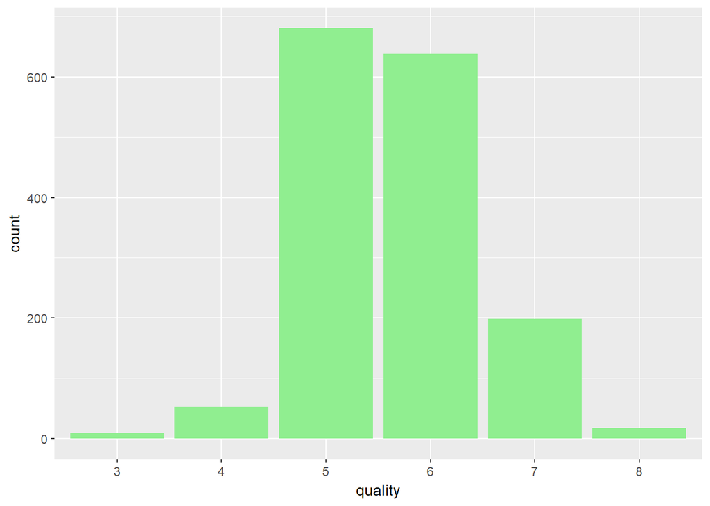

```
##   3   4   5   6   7   8
##  10  53 681 638 199  18
```

Majority of the wines in the dataset have the quality rating of 5 and 6.

FIXED ACIDITY:

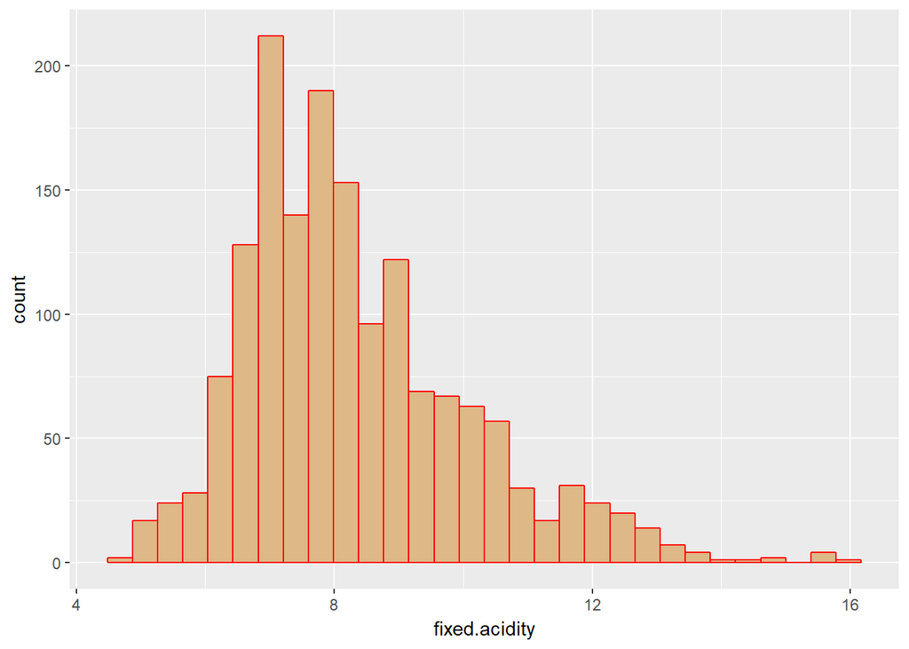

```
##    Min. 1st Qu.  Median    Mean 3rd Qu.    Max.
##    4.60    7.10    7.90    8.32    9.20   15.90
```

CITRIC ACID:

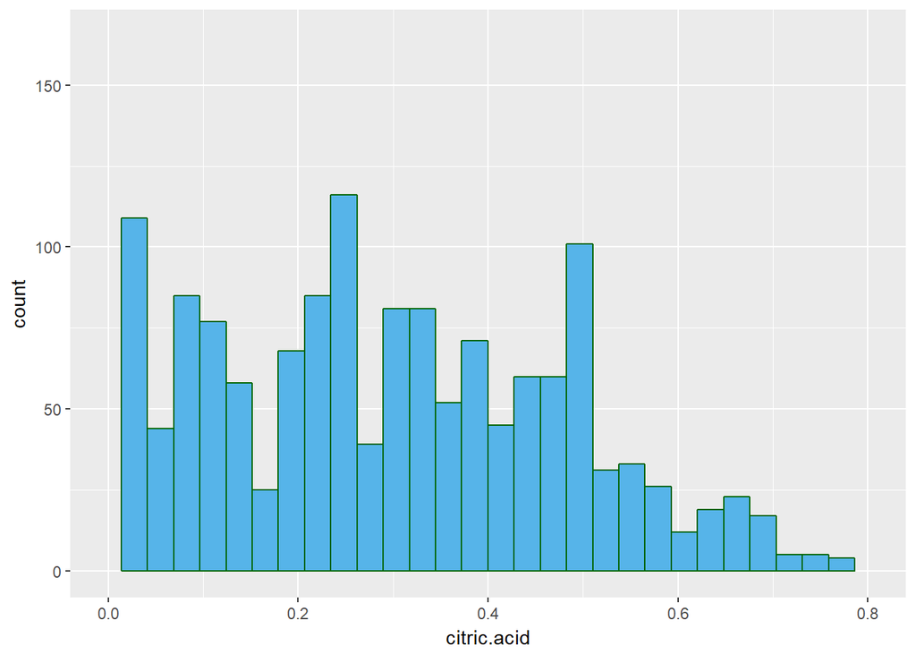

```
##
##    0 0.01 0.02 0.03 0.04 0.05 0.06 0.07 0.08 0.09  0.1 0.11 0.12 0.13 0.14
##  132   33   50   30   29   20   24   22   33   30   35   15   27   18   21
## 0.15 0.16 0.17 0.18 0.19  0.2 0.21 0.22 0.23 0.24 0.25 0.26 0.27 0.28 0.29
##   19    9   16   22   21   25   33   27   25   51   27   38   20   19   21
##  0.3 0.31 0.32 0.33 0.34 0.35 0.36 0.37 0.38 0.39  0.4 0.41 0.42 0.43 0.44
##   30   30   32   25   24   13   20   19   14   28   29   16   29   15   23
## 0.45 0.46 0.47 0.48 0.49  0.5 0.51 0.52 0.53 0.54 0.55 0.56 0.57 0.58 0.59
##   22   19   18   23   68   20   13   17   14   13   12    8    9    9    8
##  0.6 0.61 0.62 0.63 0.64 0.65 0.66 0.67 0.68 0.69  0.7 0.71 0.72 0.73 0.74
##    9    2    1   10    9    7   14    2   11    4    2    1    1    3    4
## 0.75 0.76 0.78 0.79    1
##    1    3    1    1    1
```

citric acid is found in small quantities. citric acid can add ‘freshness’ and flavor to wines.There are many zero values for this variable.

ALCOHOL:

The alcohol content is another important aspect to consider when we are purchasing wine:

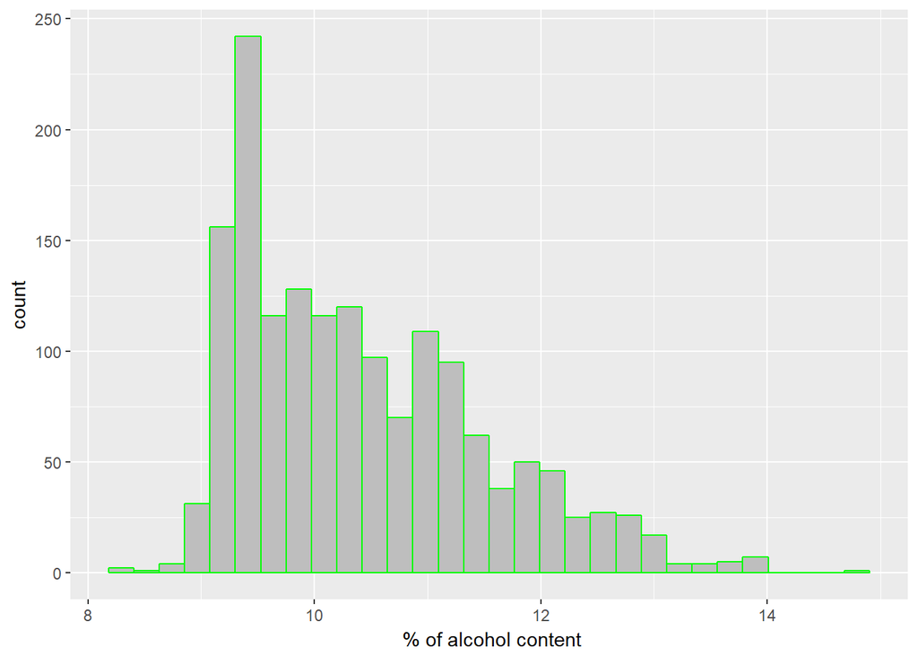

```
##    Min. 1st Qu.  Median    Mean 3rd Qu.    Max.
##    8.40    9.50   10.20   10.42   11.10   14.90
```

```
## [1] 0.7404628
```

In almost 75% of the wines, percentage of alcohol content is around 9.5 to 11 .

RESIDUAL SUGAR AND CHLORIDES :

The residual sugar is the amount of sugar remaining after fermentation stops. It’s rare to find wines with less than 1 gram/liter and wines with greater than 45 grams/liter are considered sweet. The wines in our dataset have maximum 15% residual sugar ,which means they are not sweet.

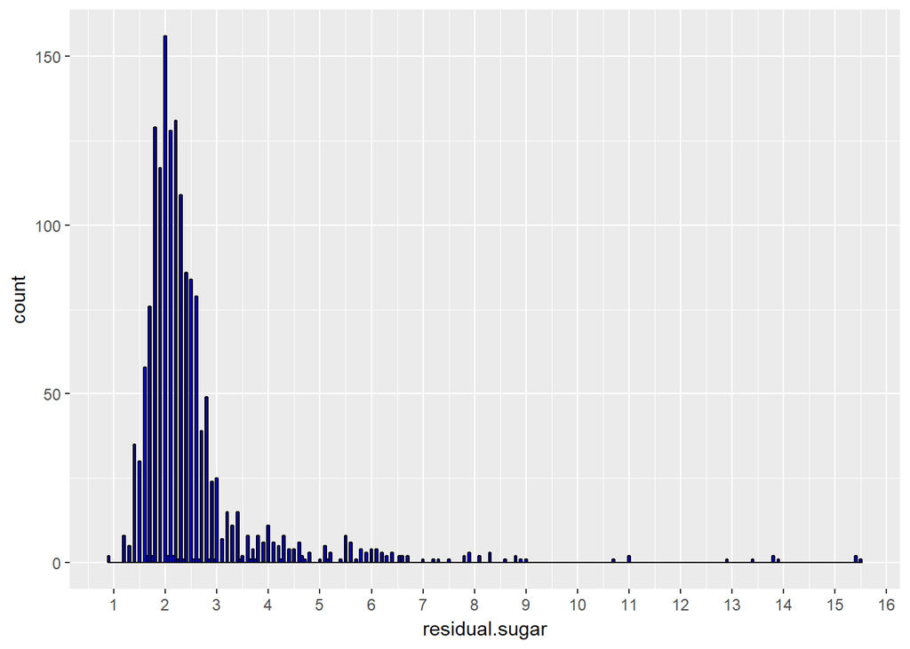

```r
ggplot(aes(x=residual.sugar), data=wine) +
  geom_histogram(binwidth=0.05, fill='blue', colour='black') +
  scale_x_continuous(breaks=0:16)
```

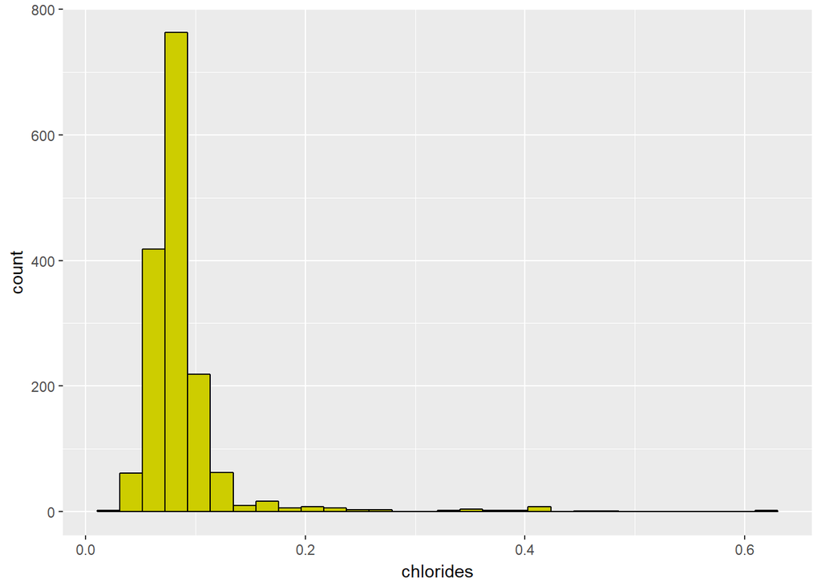

```r
# This is has too many outliers. lets exclude the 95th percentile

ggplot(aes(x = chlorides), data = wine) +
  geom_histogram(fill = 'yellow3', colour = 'black')
```

Plotting the histogram of residual sugar and chlorides, we see many outliers. Excluded the 95th percentile and plotted again. I added a log scale to get a normalized distribution.

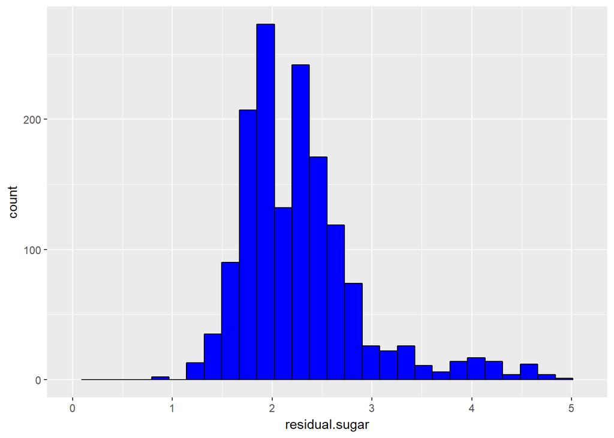

```r
ggplot(wine, aes(x=residual.sugar)) +
  geom_histogram(fill='blue', colour='black') +
  scale_x_log10(breaks=seq(1,6,1)) +
  xlim(0, quantile(wine$residual.sugar, c(0.95)))
```

```r
summary(wine$residual.sugar)
```

```
##    Min. 1st Qu.  Median    Mean 3rd Qu.    Max.
##   0.900   1.900   2.200   2.539   2.600  15.500
```

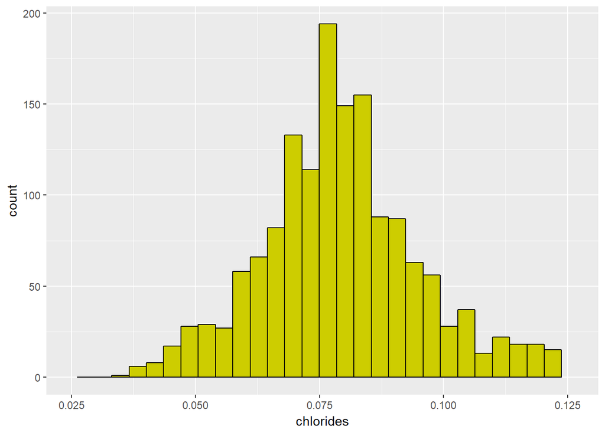

```r
ggplot(aes(x = chlorides ), data =wine) +
  geom_histogram(fill='yellow3', colour='black') +
  scale_x_log10()+
  xlim(0.025, quantile(wine$chlorides, c(0.95)))
```

# Univariate Analysis

### What is the structure of your dataset?

There are 1599 observations of 13 variables

### What is/are the main feature(s) of interest in your dataset?

Quality is the main feature of interest.

### What other features in the dataset do you think will help support your investigation into your feature(s) of interest?

Fixed acidity, citric acid, residual sugar,alcohol,chlorides are also features to be considered while investigating the quality.

### Did you create any new variables from existing variables in the dataset?

Yes I will be creating one new variable for categorising the quality rating.

### Of the features you investigated, were there any unusual distributions?

Citric acid had unusual distribution as there are many with 0 as the value (about 132 instances).

Residual sugar and chlorides had the maximum outliers.

### Did you perform any operations on the data to tidy, adjust, or change the form of the data? If so, why did you do this?

Not many changes need to be done as the dataset is already tidy. I removed the index variable X as it is not necessary for the analysis.I also changed the quality variable to factor so that we can plot each of them easily.

# Bivariate Plots Section

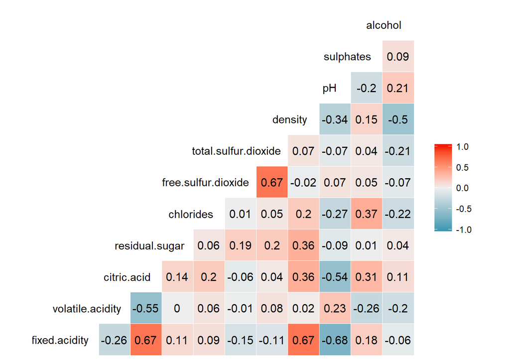

```r
ggcorr(wine,label= TRUE, hjust = 0.9,layout.exp = 1, label_round = 2)
```

```r
# this shows the corr coeff of variables. so we can decide which ones to
#concentrate on.
```

Points to consider:

*alcohol:quality = 0.48

*sulphates:quality = 0.25

*citric.acid:quality = 0.23

*fixed.acidity:quality = 0.12

Let us plot them for better understanding.

[figure not shown]

As we saw in univariate analysis, it is evident that quality increases as the percentage of alcohol increases. The summary statistics for alcohol:

```
## wine$quality: 3
##    Min. 1st Qu.  Median    Mean 3rd Qu.    Max.
##   8.400   9.725   9.925   9.955  10.575  11.000
## --------------------------------------------------------
## wine$quality: 4
##    Min. 1st Qu.  Median    Mean 3rd Qu.    Max.
##    9.00    9.60   10.00   10.27   11.00   13.10
## --------------------------------------------------------
## wine$quality: 5
##    Min. 1st Qu.  Median    Mean 3rd Qu.    Max.
##     8.5     9.4     9.7     9.9    10.2    14.9
## --------------------------------------------------------
## wine$quality: 6
##    Min. 1st Qu.  Median    Mean 3rd Qu.    Max.
##    8.40    9.80   10.50   10.63   11.30   14.00
## --------------------------------------------------------
## wine$quality: 7
##    Min. 1st Qu.  Median    Mean 3rd Qu.    Max.
##    9.20   10.80   11.50   11.47   12.10   14.00
## --------------------------------------------------------
## wine$quality: 8
##    Min. 1st Qu.  Median    Mean 3rd Qu.    Max.
##    9.80   11.32   12.15   12.09   12.88   14.00
```

It is surprising to see sulphates,a wine additive which can contribute to sulfur dioxide gas (S02) levels has so much to do with quality. I later learnt that sulphates do act as an antimicrobial and antioxidant and thats what makes it so important.As concentration of sulphate increases, quality does increase. The summary statistics :

```
## wine$quality: 3
##    Min. 1st Qu.  Median    Mean 3rd Qu.    Max.
##  0.4000  0.5125  0.5450  0.5700  0.6150  0.8600
## --------------------------------------------------------
## wine$quality: 4
##    Min. 1st Qu.  Median    Mean 3rd Qu.    Max.
##  0.3300  0.4900  0.5600  0.5964  0.6000  2.0000
## --------------------------------------------------------
## wine$quality: 5
##    Min. 1st Qu.  Median    Mean 3rd Qu.    Max.
##   0.370   0.530   0.580   0.621   0.660   1.980
## --------------------------------------------------------
## wine$quality: 6
##    Min. 1st Qu.  Median    Mean 3rd Qu.    Max.
##  0.4000  0.5800  0.6400  0.6753  0.7500  1.9500
## --------------------------------------------------------
## wine$quality: 7
##    Min. 1st Qu.  Median    Mean 3rd Qu.    Max.
##  0.3900  0.6500  0.7400  0.7413  0.8300  1.3600
## --------------------------------------------------------
## wine$quality: 8
##    Min. 1st Qu.  Median    Mean 3rd Qu.    Max.
##  0.6300  0.6900  0.7400  0.7678  0.8200  1.1000
```

These variables have negative correlation with quality:

*volatile.acidity:quality = -0.39

*total.sulfur.dioxide:quality = -0.19

*density:quality = -0.17

*chlorides:quality = -0.13

Note the highest negative correlation is with volatile acidity. All acids in wine are non- volatile except for acetic acid which is volatile. volatile acidity is the amount of acetic acid in wine, which at too high of levels can lead to an unpleasant, vinegar taste.

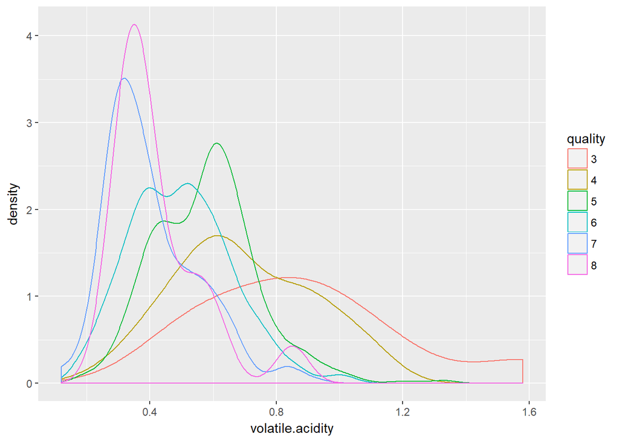

Looking at the correlation between other variables, we note :

*fixed.acidity:citric.acid = 0.67

*fixed.acidity:density = 0.67

*fixed.acidity:pH = -0.68

*free.sulfur.dioxide:total.sulfur.dioxide = 0.67

*density:alcohol = -0.50

*citric.acid:pH = -0.54

pH describes how acidic or basic a wine is on a scale from 0 (very acidic) to 14 (very basic). Thus when citric acid increases, pH decreases indicating that the wine is getting more acidic. Fixed acidity includes acidity of citric acid also, as it is a non volatile acid. Obviously citric acid and fixed acidity are positively correlated. Thus pH decreases with increase in fixed acidity.

On Plotting the relationship between fixed acidity and other variables, we can understand the pattern in detail.

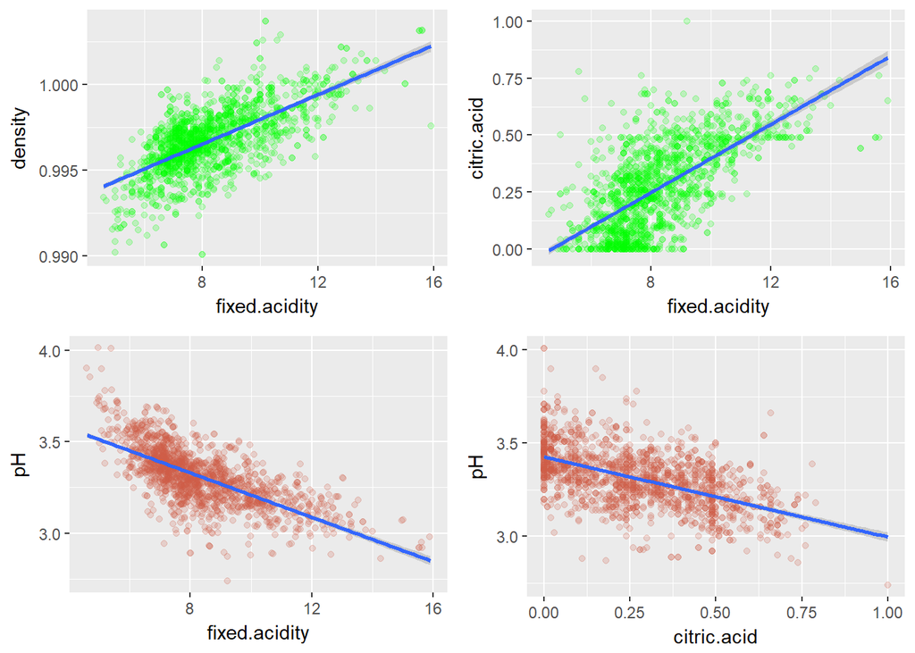

Fixed acidity is positively correlated with density and citric acid . Both fixed acidity and citric acid have inverse relationship with pH.

Similarly, total sulfur dioxide is the amount of free and bound forms of S02. Hence, when free sulfur dioxide increases, total sulfur dioxide also increases.

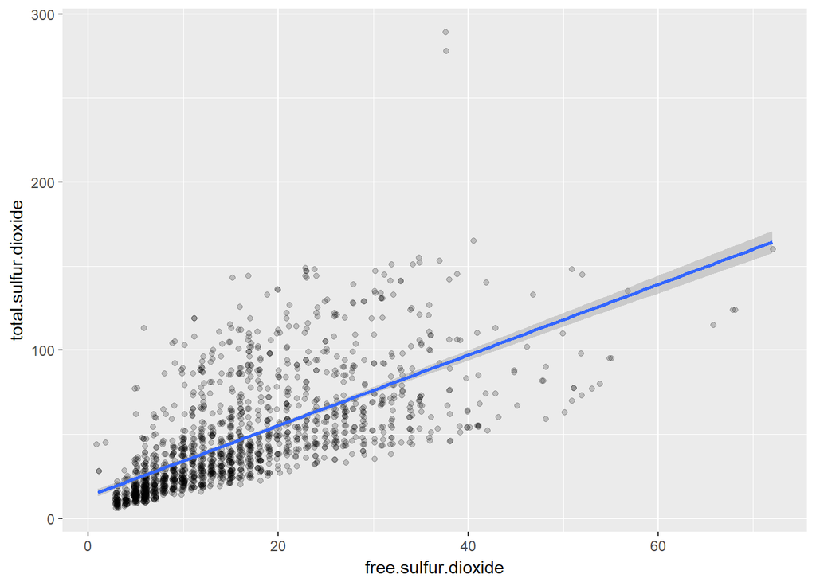

One other important relationship to note is the negative correlation of density and alcohol.

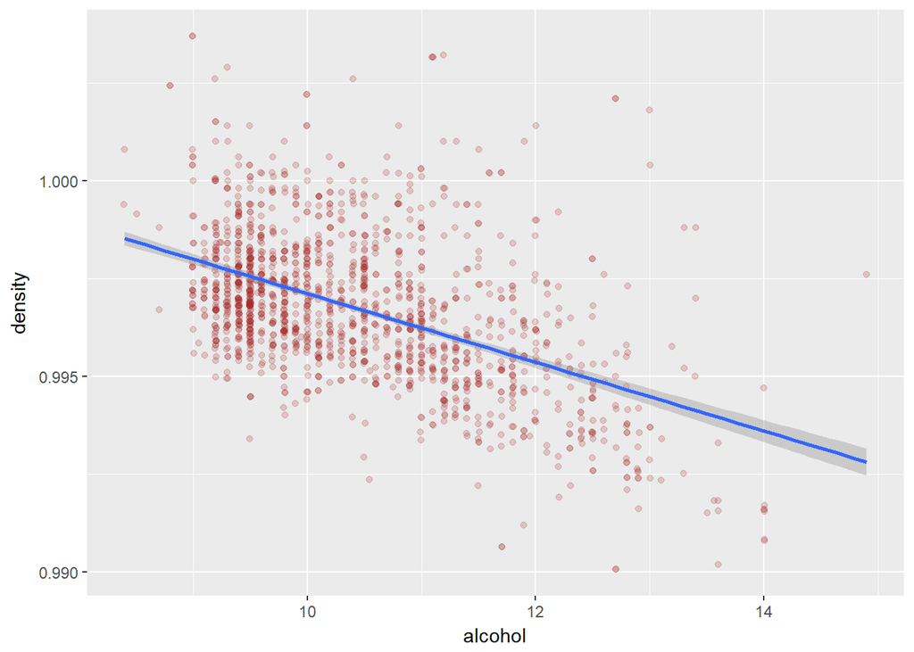

# Bivariate Analysis

### Talk about some of the relationships you observed in this part of the investigation. How did the feature(s) of interest vary with other features in the dataset?

Quality is positively correlated to alcohol, sulphates, fixed acidity. It is neagtively correlated to volatile acidiity.

### Did you observe any interesting relationships between the other features (not the main feature(s) of interest)?

Yes. Fixed acidity had positive correlations with density and citric acid. whereas, it exhibited inverse relationship with pH.

### What was the strongest relationship you found?

Alcohol exhibited strongest relationship with quality. When comparing other variables, fixed acidity and pH had the strongest negative correlation.

# Multivariate Plots Section

The main factors which determine the quality are alcohol and sulphates. Lets plot them to see their relationships.

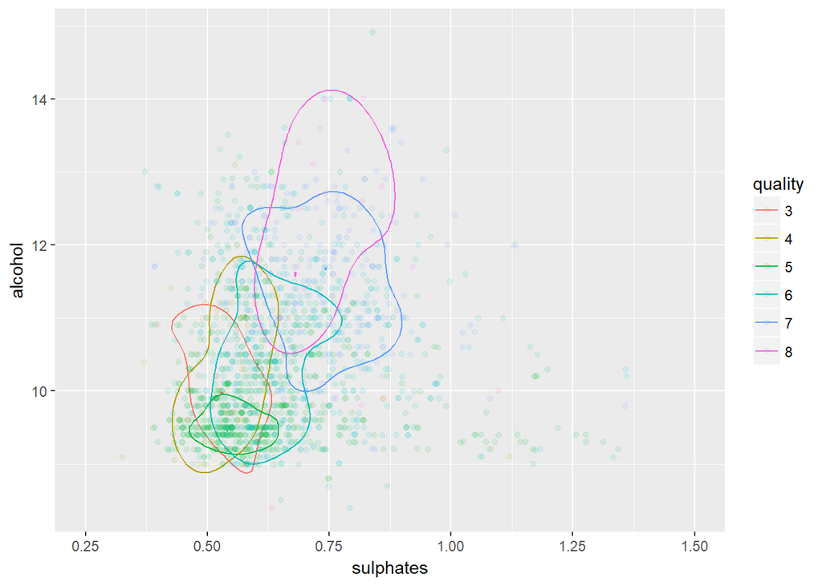

In the above plot, higher quality wines are at the top right and lower quality wines are at the bottom left. Though we can plot various variables against quality, Let us categorise the quality ratings so as to get a more clear picture. The quality ratings are from 3 to 8.

Let us categorise them as low, average, good and high quality wines based on the rating.

```r
wine <- mutate(wine, rating =
                 ifelse(quality < 5, 'Low',
                   ifelse(quality == 5 , 'Average',
                   ifelse(quality == 6 , 'Good', 'High'))))
wine$rating <- factor(wine$rating,
                             levels=c("Low", "Average", "Good", "High"))

summary(wine$rating)
```

```
##     Low Average    Good    High
##      63     681     638     217
```

Now let us replot the earlier plot with rating variable.

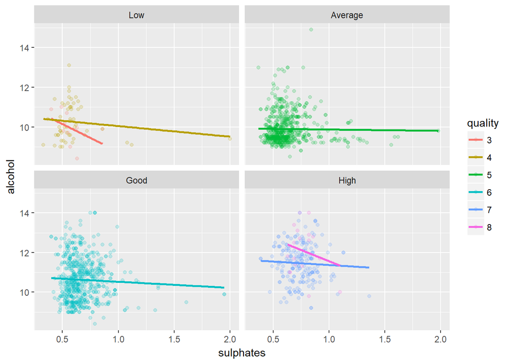

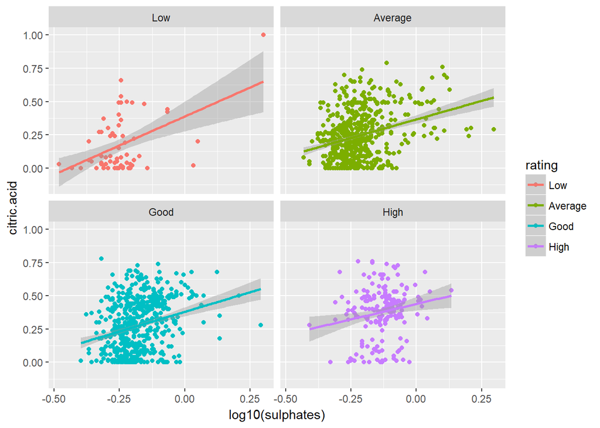

Plotting density and alcohol

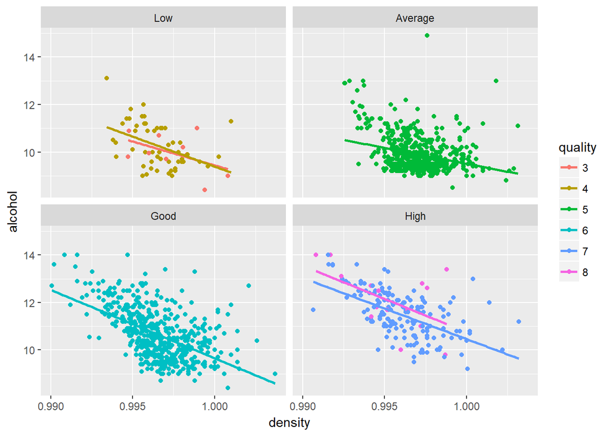

With increase in percentage of alcohol, density decreases. High quality wines have higher percentage of alcohol in them, but may be with a fine balance with the density.

# Multivariate Analysis

### Talk about some of the relationships you observed in this part of the investigation. Were there features that strengthened each other in terms of looking at your feature(s) of interest?

I observed that lower density and higher alcohol content gives a good wine. Higher quantity of sulphates and citric.acid makes a good wine too but with lower volatile acidity only.

### Were there any interesting or surprising interactions between features?

Volatile acidity, fixed acidity and pH must be finely balanced to get the best quality wine.

### OPTIONAL: Did you create any models with your dataset? Discuss the strengths and limitations of your model.

NO.

# Final Plots and Summary

### Plot One

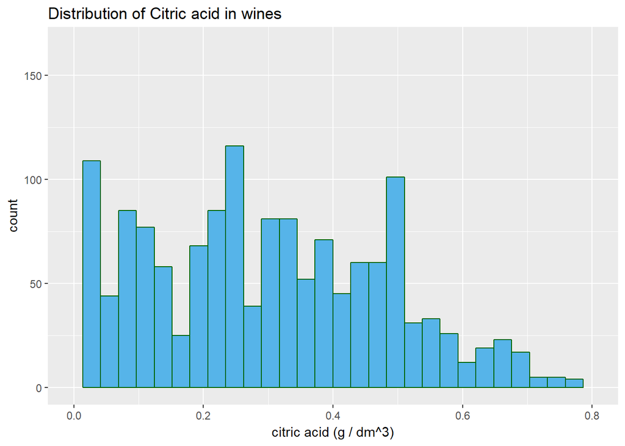

### Description One

Citric acid has a nice positive correlation with quality(0.23). So I plotted it understand it better. To my surprise, very very small quantity (< 1 g) of citric acid was added to wine. Many wines didnot have citric acid at all (0 g/ltr). I thought it was because of inadequate data. Deeper analysis revealed there are many wines which doesnt have citric acid in it (according to tests conducted by the Food Standards Australia New Zealand website). The data and the analysis of our dataset reveals the same result.

### Plot Two

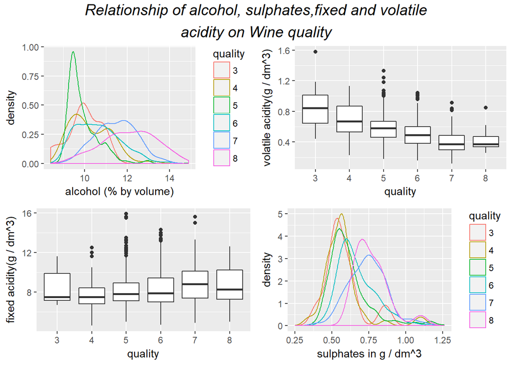

### Description Two

The main factors which determine the quality of the wine have been plotted. Percentage of alcohol, fixed acidity and sulphates have positive effect on quality. Wine quality and volatile acidity are negatively correlated. In all cases, we see outliers in quality ratings 5 and 6 , showing there may be other factors that influence quality.

### Plot Three

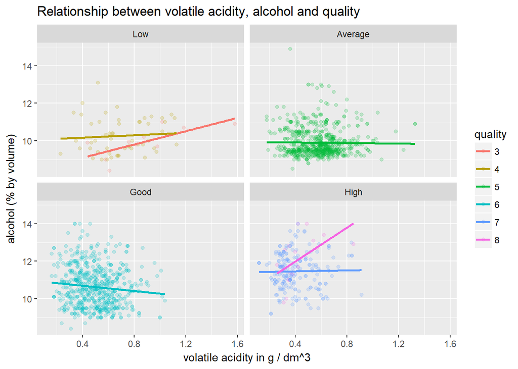

### Description Three

The two strong positively correlated(alcohol) and negatively correlated(volatile. acidity) factors have been plotted against quality. It is understood that high alcohol and low volatile acidity might give higher quality wines. Please note that volatile acid , acetic acid can contribute to wine fault , which might make the wine undrinkable.

# Reflection

This red wine dataset has 1599 observations and 13 variables.This is a perfectly tidy and small dataset to be used for EDA by beginners.The step-by- step approach from univariate to bivariate and then to multivariate plots was a nice way to explore a dataset. It is clear from the outset , the main factors that determine the quality. but plotting the correlations revealed more insights.I guessed alcohol would be one of the main contributor. Surprisingly, sulphates and acetic acid do have roles to play. Citric acid, though correlated well, was added in very less quantities and doesnot have much effect except for the freshness in wines.

Future work would be to build a model to predict the wine quality. This dataset had more wines with rating 5 and 6. May be the next step would be to get more data on wines with other quality ratings too.

The main struggle I faced was finding an apt dataset and tidying it. I was initially browsing thro various data and chose a few. Looking in detail, there were many NAs, repetitions and a whole big bunch of data, which I did not know how to interpret. As it was taking way too much of time, I resented to one of the suggested datasets. It was worth a decision. I was able to learn a lot from this red wine dataset. Had I taken some other big dataset, I would have focussed on tidying rather than exploring the dataset.